# How to Lose Less Money Playing the Lottery

Friday, June 19, 2015

## Real Goal: Understanding players' preferences

- Players prefer some numbers, such as family birthdays, 7's, etc.
- Direct data exist but are not public, so how can we document this?
- Can gain some insight by relating number of winners to numbers drawn.
- Number of winners is only informative if total number of players is known.
- Otherwise we can model parimutuel prizes as a function of the numbers drawn.

## Games Discussed Here

- Texas Cash 5
  - Players and lottery choose 5 integers from 1 to 37
  - Target prize for 3 matches is $10.00
  - Jan. 1, 2012 to June 12, 2015
- Pennsylvania Cash 5
  - Players and lottery choose 5 integers from 1 to 43
  - Target prize for 3 matches is $11.50
  - Jan. 1, 2012 to June 12, 2015
- New Jersey Cash 5
  - Players and lottery choose 5 integers from 1 to 43
  - Target prize for 3 matches is $15.00
  - Sept. 14, 2014 to June 12, 2015

## Random vs. Actual, Texas

```r
dhyper(3,5,32,5)
```

```
## [1] 0.01137883
```

```r
tx.actual <- read.table("tx_data\\tx_cash5.csv",header=TRUE,sep=",")
sum(tx.actual$winners_3)/sum(tx.actual$sales)
```

```
## [1] 0.01137874
```

## Random vs. Actual, Texas

```r
draws <- nrow(tx.actual)
pop <- 150000
prob <- dhyper(3,5,32,5)
pool <- sum(tx.actual$prize_3*tx.actual$winners_3)/sum(tx.actual$sales)

set.seed(12345)
sim.winners <- rpois(draws,pop*prob)
sim.prizes <- round(pop*pool/sim.winners)
sim.pct.win <- sim.winners/pop

actual.prizes <- tx.actual$prize_3
actual.pct.win  <- tx.actual$winners_3/tx.actual$sales
```

## Random vs. Actual, Texas

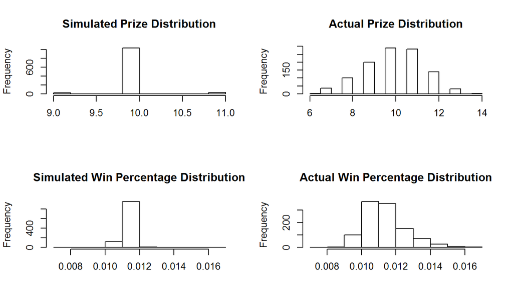

## Random vs. Actual, Pennsylvania

```r
pa.actual <- read.table("pa_data\\pa_cash5.csv",header=TRUE,sep=",")

draws <- nrow(pa.actual)
pop <- 400000
prob <- dhyper(3,5,38,5)
pool <- prob*mean(pa.actual$prize_3)

set.seed(54321)
sim.winners <- rpois(draws,pop*prob)
sim.prizes <- 0.5*round(2*pop*pool/sim.winners)

actual.prizes <- pa.actual$prize_3
```

## Random vs. Actual, Pennsylvania

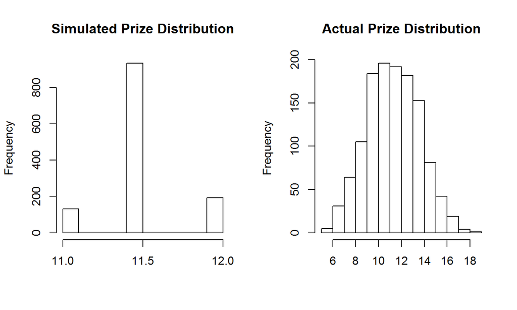

## Modeling When Sales Data Are Available

Poisson Regression

Model TX1: \[ \ln(y) = \beta t + c +\ln(s)\]

where \(y\) is the number of 3-match winners, \(t\) is the sum of the numbers drawn, and \(s\) is sales.

Interpretation: \[\beta t + c\] estimates the log of the percentage of players who match 3 numbers.

## Modeling When Sales Data Are Available

```r
tx.actual$drawdate <- as.Date(as.character(tx.actual$drawdate))
tx.actual <- mutate(tx.actual,draw_sum=n1+n2+n3+n4+n5)
tx.train <- tx.actual[tx.actual$drawdate <= '2014-06-12',]
tx.test <- tx.actual[tx.actual$drawdate > '2014-06-12',]
tx1 <- glm(winners_3~draw_sum,data=tx.train,
              family=poisson,
              offset=log(sales))
knitr::kable(summary(tx1)$coefficients,digits=4)
```

|  | Estimate | Std. Error | z value | Pr(>\|z\|) |
| --- | --- | --- | --- | --- |
| (Intercept) | -4.2494 | 0.0032 | -1327.7888 | 0 |
| draw_sum | -0.0024 | 0.0000 | -72.2789 | 0 |

## Validating on Recent Data

```r
tx.test$predict <- predict(tx1,tx.test,type="response")
```

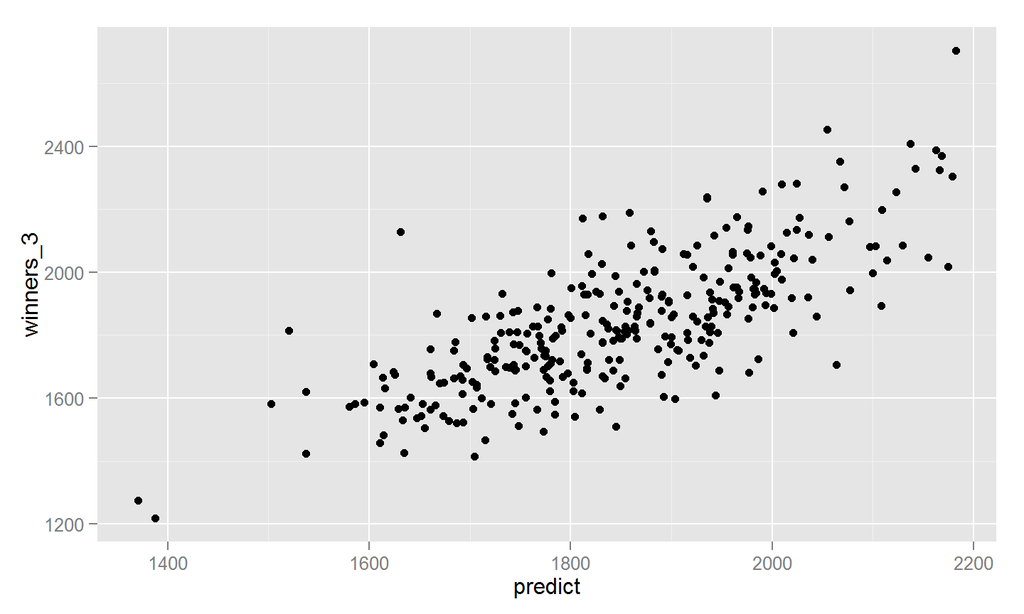

## Modeling Prize Amounts

Without sales data, we resort to modeling prizes as a function of the numbers drawn. Linear models are not justifiable from an inference point of view, but they could provide good predictions.

Model PA1:  
\[ y = \beta t + c\]  
where \(y\) is the 3-match prize and \(t\) is the sum of the numbers drawn.

## Modeling Prize Amounts

```r
pa.actual$drawdate <- as.Date(as.character(pa.actual$drawdate))
pa.actual <- mutate(pa.actual,draw_sum=n1+n2+n3+n4+n5)
pa.train <- pa.actual[pa.actual$drawdate <= '2014-06-12',]
pa.test <- pa.actual[pa.actual$drawdate > '2014-06-12',]
```

```r
pa1 <- lm(prize_3~draw_sum,data=pa.train)
knitr::kable(summary(pa1)$coefficients,digits=4)
```

|  | Estimate | Std. Error | t value | Pr(>\|t\|) |
| --- | --- | --- | --- | --- |
| (Intercept) | 3.6864 | 0.1751 | 21.0561 | 0 |
| draw_sum | 0.0714 | 0.0016 | 45.9836 | 0 |

```r
print(summary(pa1)$adj.r.squared)
```

[1] 0.7029757

## Modeling Prize Amounts

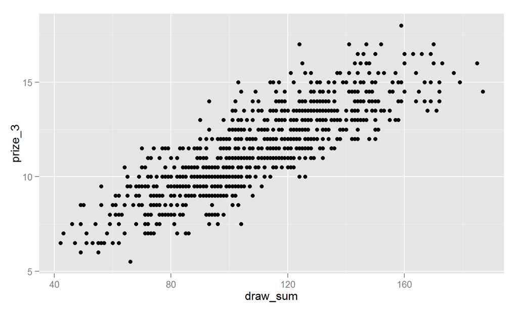

## Some Refinements

Besides small numbers, players tend to choose combinations of numbers that are physically close on a playslip. So we'll add variables to proxy combinations selected along a row or column.

```r
library(magrittr)

pa.train <- mutate(pa.train,range=n5-n1) %>%
            mutate(spacing =
                  sqrt((((n2-n1)^2+(n3-n2)^2+(n4-n3)^2+(n5-n4)^2)/4)-
                               ((n5-n1)/4)^2))
```

## Some Refinements

Model PA2:  
\[ y = \beta_1 t + \beta_2 r + \beta_3 s + c\]  
where \(y\) is the 3-match prize, \(t\) is the sum of the numbers drawn, \(r\) is the range of the numbers drawn, and \(s\) is the standard deviation of the gaps between consecutive numbers drawn.

## Some Refinements

```r
pa2 <- lm(prize_3~draw_sum+range+spacing,data=pa.train)
knitr::kable(summary(pa2)$coefficients,digits=4)
```

|  | Estimate | Std. Error | t value | Pr(>\|t\|) |
| --- | --- | --- | --- | --- |
| (Intercept) | 1.2168 | 0.2158 | 5.6384 | 0 |
| draw_sum | 0.0733 | 0.0014 | 54.1661 | 0 |
| range | 0.0553 | 0.0059 | 9.3640 | 0 |
| spacing | 0.1250 | 0.0194 | 6.4286 | 0 |

```r
print(summary(pa2)$adj.r.squared)
```

[1] 0.7759713

## Some Refinements

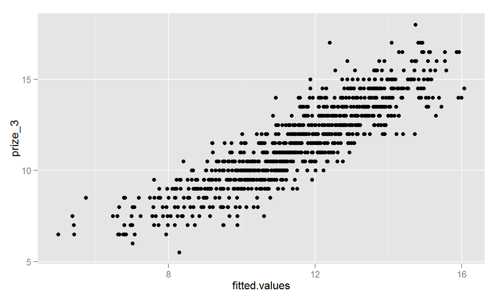

## Interaction: Time Since Last Jackpot

Habitual players may have a stronger tendency to choose "favorite" numbers. So we calculate where each draw is in the sequence since the last jackpot.

```r
draw.since.jp <- function(x) {
    jp.dates <- filter(pa.actual, prize_5 > 0 & drawdate < x) %>%
                arrange(desc(drawdate))

    return(nrow(filter(pa.actual,
                       drawdate > jp.dates$drawdate[1] &
                       drawdate <= x)))
}

pa.train <- filter(pa.train, drawdate >
                       min(pa.actual$drawdate[pa.actual$prize_5>0]))

pa.train$draw.since.jp <- sapply(pa.train$drawdate,draw.since.jp)
```

## Interaction: Time Since Last Jackpot

```r
pa3 <- lm(prize_3~draw_sum*draw.since.jp,data=pa.train)
knitr::kable(summary(pa3)$coefficients,digits=4)
```

|  | Estimate | Std. Error | t value | Pr(>\|t\|) |
| --- | --- | --- | --- | --- |
| (Intercept) | 1.5626 | 0.3234 | 4.8317 | 0 |
| draw_sum | 0.0928 | 0.0029 | 32.0328 | 0 |
| draw.since.jp | 0.8235 | 0.1057 | 7.7920 | 0 |
| draw_sum:draw.since.jp | -0.0083 | 0.0010 | -8.7166 | 0 |

```r
print(summary(pa3)$adj.r.squared)
```

[1] 0.7276371

## Interaction: Time Since Last Jackpot

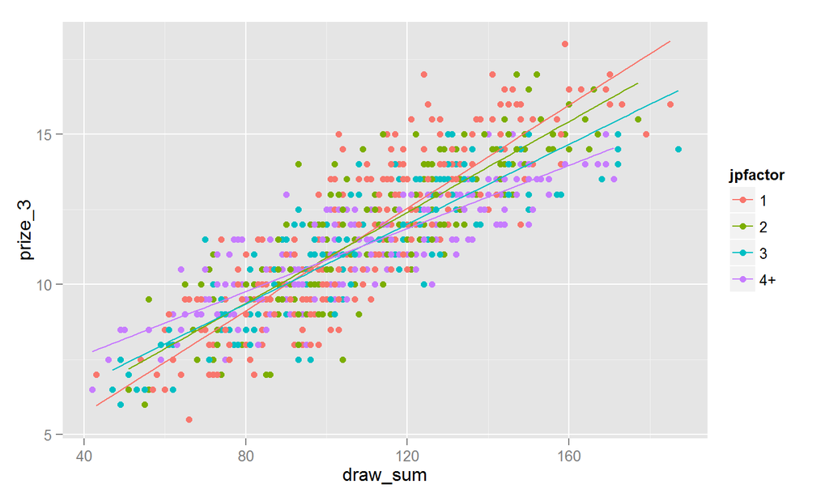

## Interaction: Time Since Last Jackpot

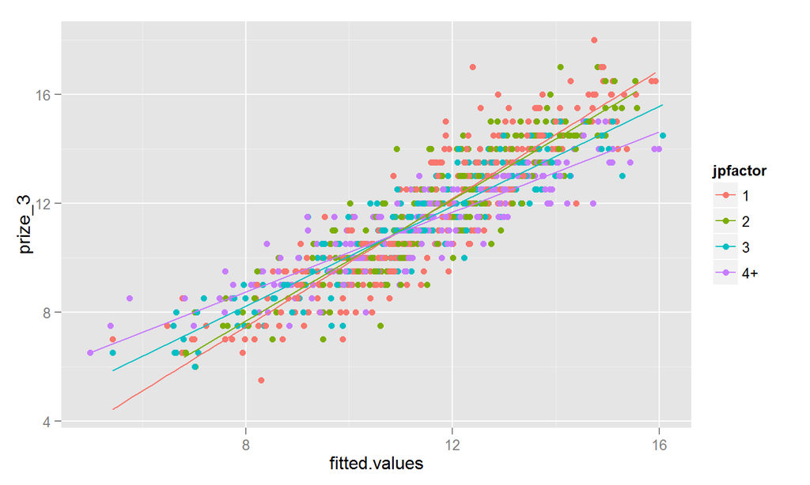

## Putting It All Together

```r
tsjp.train <- split(pa.train,pa.train$jpfactor)

pai <- lapply(tsjp.train,
              function(x) lm(prize_3~draw_sum+range+spacing,data=x))
```

## Validating on Recent Data

```r
pa.test <- mutate(pa.test,range=n5-n1) %>%
            mutate(spacing =
                  sqrt((((n2-n1)^2+(n3-n2)^2+(n4-n3)^2+(n5-n4)^2)/4)-
                               ((n5-n1)/4)^2))

pa.test$draw.since.jp  <- sapply(pa.test$drawdate,draw.since.jp)

pa.test$jpfactor <- cut(pa.test$draw.since.jp,
                     cutpoints,
                     include.lowest=TRUE,
                     right = FALSE)
pa.test$jpfactor <- as.character(pa.test$jpfactor)

pa.test$jpfactor <- sapply(pa.test$jpfactor,rename)
```

## Validating on Recent Data

```r
pa.test$predict1 <- predict(pa1,pa.test)
pa.test$predict2 <- predict(pa2,pa.test)
```

## Validating on Recent Data

```
## [1] 1.337797
```

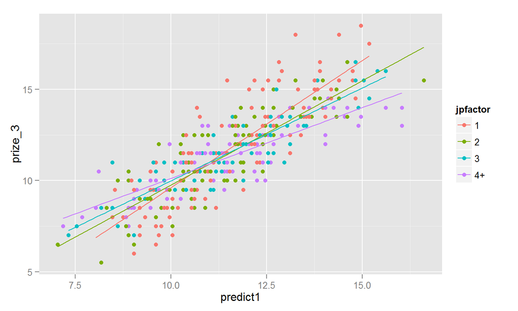

## Validating on Recent Data

```
## [1] 1.186056
```

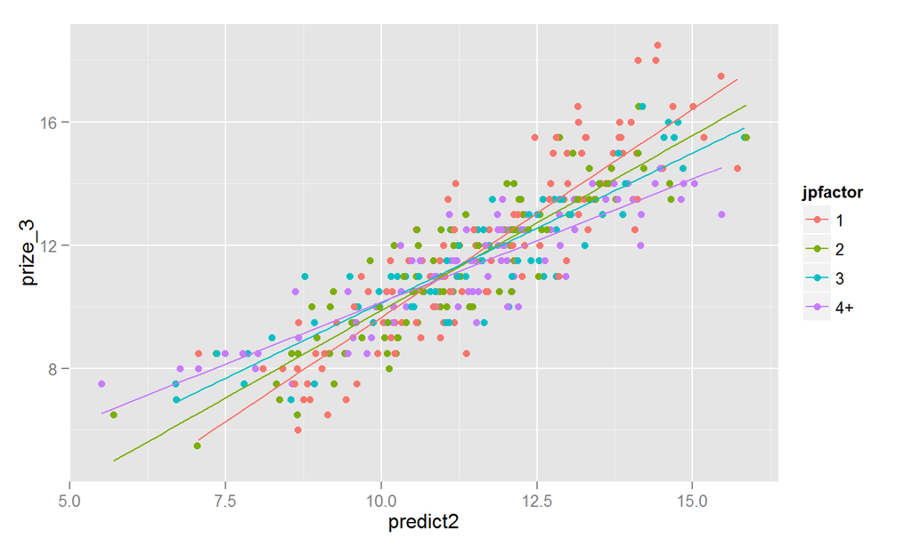

## Validating on Recent Data

```r
tsjp.test <- split(pa.test,pa.test$jpfactor)
tsjp.test[[1]]$predict3 <- predict(pai[[1]],tsjp.test[[1]])
tsjp.test[[2]]$predict3 <- predict(pai[[2]],tsjp.test[[2]])
tsjp.test[[3]]$predict3 <- predict(pai[[3]],tsjp.test[[3]])
tsjp.test[[4]]$predict3 <- predict(pai[[4]],tsjp.test[[4]])
```

## Validating on Recent Data

```
## [1] 1.121879
```

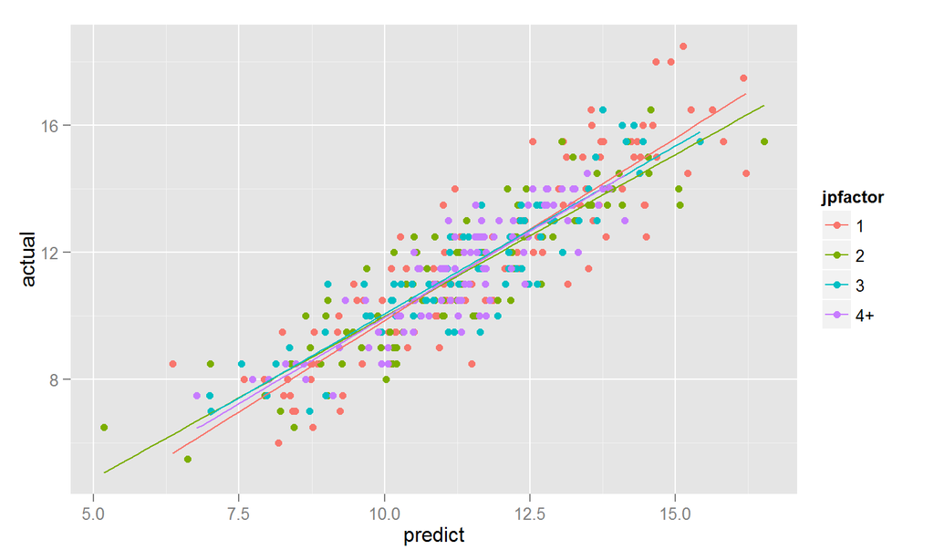

## Validating on New Jersey Data

```r
nj.test <- read.table("nj_data\\nj_cash5.csv",header=TRUE,sep=",") %>%
           mutate(draw_sum=n1+n2+n3+n4+n5) %>%
           mutate(range=n5-n1) %>%
           mutate(spacing =
                  sqrt((((n2-n1)^2+(n3-n2)^2+(n4-n3)^2+(n5-n4)^2)/4)-
                               ((n5-n1)/4)^2))
```

## Validating on New Jersey Data

```r
prize.adjust <- mean(nj.test$prize_3)/mean(pa.actual$prize_3)
nj.test$predict1 <- prize.adjust*predict(pa1,nj.test)
nj.test$predict2 <- prize.adjust*predict(pa2,nj.test)
```

## Validating on New Jersey Data

```
## [1] 1.56877
```

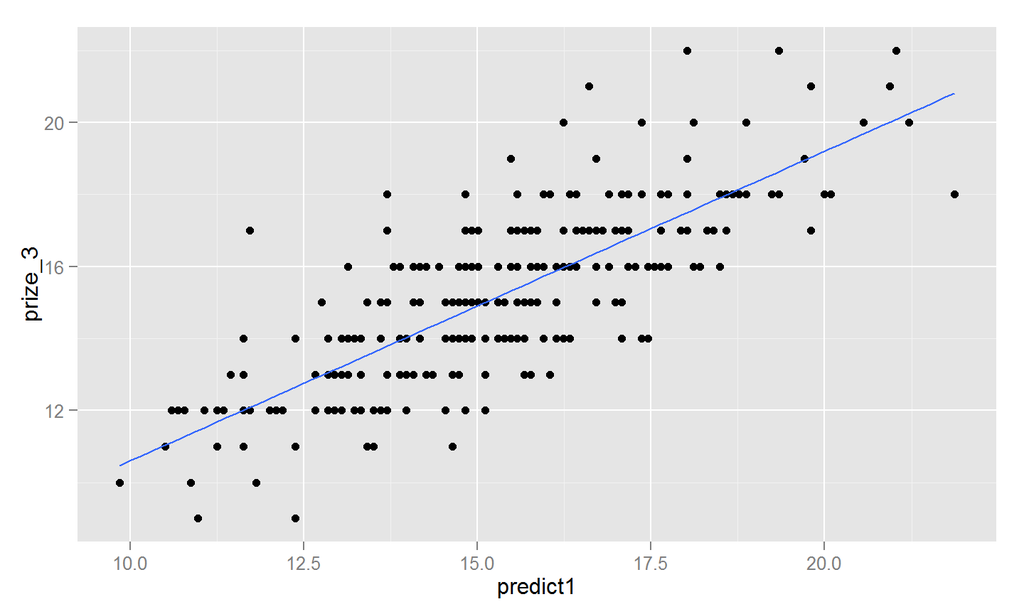

## Validating on New Jersey Data

```
## [1] 1.297411
```

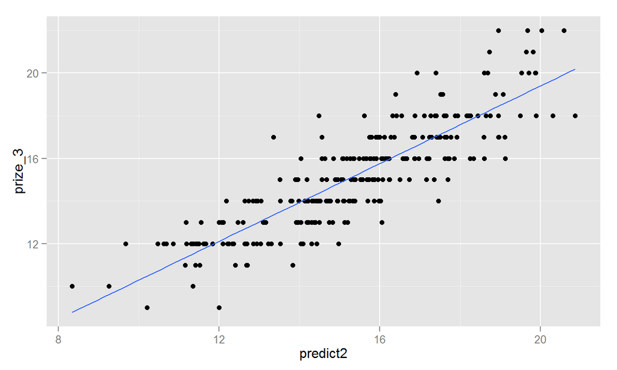

## Getting Data

- New Jersey was all manual.  
  https://www.njlottery.com/en-us/drawgames/dailygames/jerseycash.html
- Pennsylvania was semi-manual. You can choose "Cash 5" and a year from the page below and store the resulting page in a text file. Then you can parse these files to get the URLS and scrape the appropriate pages.  
  http://www.palottery.state.pa.us/Games/Past-Winning-Numbers.aspx
- Texas was fully automated!

## References

- My github repo  
  https://github.com/lotterdata/mis_presentation
- Number selection algorithm exploiting this idea  
  http://www.r-bloggers.com/picking-lotto-numbers/
- A recent article in a similar vein  
  http://www.r-bloggers.com/simple-data-science-to-maximize-return-on-lottery-investment/